# **Ali Padyav - 810199388**

### **AI - CA5 - NN** (Part 1,2,3)

1- Preprocessing

```python
import numpy as np
import pandas
import matplotlib.pyplot as plt
from numpy.typing import NDArray
from pandas.core.frame import DataFrame
```

```python
train_imgs = pandas.read_csv(f'AI-CA5-Dataset/TrainImgs.csv', header=None)
train_labels = pandas.read_csv(f'AI-CA5-Dataset/TrainLabels.csv', header=None)
test_imgs = pandas.read_csv(f'AI-CA5-Dataset/TestImgs.csv', header=None)
test_labels = pandas.read_csv(f'AI-CA5-Dataset/TestLabels.csv', header=None)
```

```python
def row_to_square(row):
    return row.values.reshape(32, 32).T
```

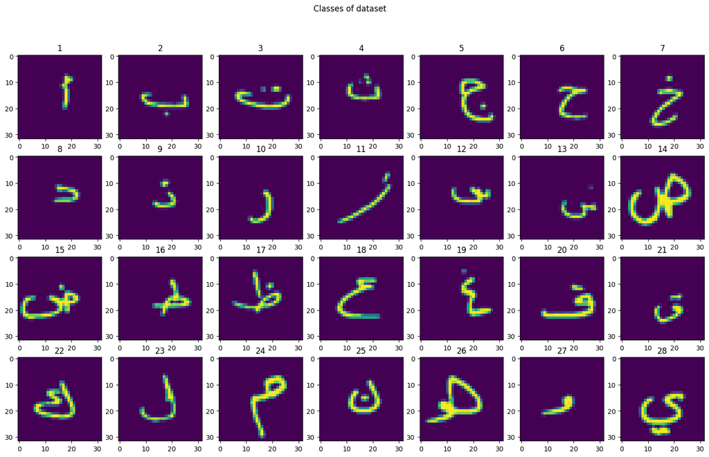

```python
sample_classes = train_imgs.assign(label=train_labels.values).groupby('label').sample()

fig, axes = plt.subplots(4, 7, figsize=(10, 8))
fig.set_size_inches(18.5, 10.5)
fig.suptitle('Classes of dataset', fontsize=12)

for i, ax in enumerate(axes.flat):
    ax.set_title(i+1)
    ax.imshow(row_to_square(sample_classes.iloc[i][:-1]))
```

```python
min_pixel_value = train_imgs.min().min()
max_pixel_value = train_imgs.max().max()

print(f'Pixel value interval: [{min_pixel_value},{max_pixel_value}]')
```

```
Pixel value interval: [0,255]
```

```python
print(f'Train data count: {train_imgs.shape[0]}')
print(f'Test data count: {test_imgs.shape[0]}')
print(f'Labels count: {train_labels[0].nunique()}')
```

```
Train data count: 13440
Test data count: 3360
Labels count: 28
```

```python
img_label = train_imgs.assign(label=train_labels.values)
img_label = img_label.loc[img_label.label <= 16]
train_imgs = img_label.iloc[:, :-1]
train_labels = DataFrame(img_label.iloc[:, -1])

img_label = test_imgs.assign(label=test_labels.values)
img_label = img_label.loc[img_label.label <= 16]
test_imgs = img_label.iloc[:, :-1]
test_labels = DataFrame(img_label.iloc[:, -1])
```

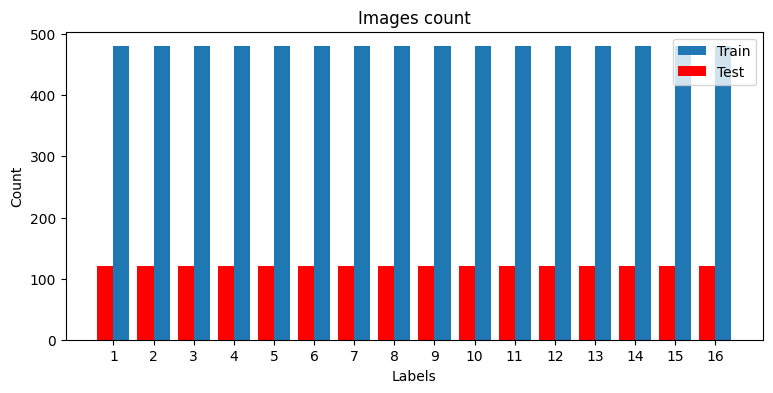

```python
labels = train_labels['label'].unique()
x_axis = np.arange(len(labels))
trainl_axis = x_axis + 0.2
testnl_axis = x_axis - 0.2

plt.figure(figsize=(9,4))
plt.bar(trainl_axis, train_labels['label'].value_counts(), 0.4, label='Train')
plt.bar(testnl_axis, test_labels['label'].value_counts(), 0.4, label='Test', color = 'red')

plt.title('Images count')
plt.xlabel('Labels')
plt.ylabel('Count')
plt.xticks(x_axis, labels)
plt.legend()
plt.show()
```

با نرمالایز کردن داده ها از ایجاد سربار محاسباتی جلوگیر میکنیم. این کار در مرحله back propagate در gradient descent نیز کمک میکند. همینوطر میتوانیم feature های مختلف را در یک اسکیل مقایسه کنیم.

```python
train_imgs = train_imgs / 255
test_imgs = test_imgs / 255
```

چون کلاس‌های ما از نوع عددی هستند ولی ترتیب خاصی ندارند با implement آن به صورت one-hot نشان میدهیم که بزرگی یا کوچکی نام کلاس نشان دهنده ویژگی ای نیست. همچنین در لایه آخر میتوانیم به تعداد کلاس‌ها نورون داشته باشیم و نورونی که بیشترین مقدار داشت را به عنواننتیجه اعلام کنیم.

```python
def one_hot_encode(train_labels):
    one_hot = np.zeros((train_labels.size, train_labels.nunique()))
    one_hot[np.arange(train_labels.size), train_labels.values - 1] = 1
    return one_hot

def softmax(data):
    exp = np.exp(data - np.max(data))
    return exp / np.sum(exp)
```

```python
one_hot_encode(train_labels['label'])
```

```
array([[1., 0., 0., ..., 0., 0., 0.],
       [1., 0., 0., ..., 0., 0., 0.],
       [1., 0., 0., ..., 0., 0., 0.],
       ...,
       [0., 0., 0., ..., 0., 0., 1.],
       [0., 0., 0., ..., 0., 0., 1.],
       [0., 0., 0., ..., 0., 0., 1.]])
```

2- Completing Classes

## Dataloader

```python
class Dataloader:
    '''
    This class prepares the dataset for the neural network.
    '''

    def __init__(self, data, labels, n_classes, batch_size=None, shuffle=False):
        '''
        Parameters:
            data: features your dataset in pandas.Dataframe format.
            labels: labels of your dataset in pandas.Dataframe format.
            n_classes: number of classes you have in your dataset.
            batch_size: the number of samples that will be propagated through the network.
            shuffle: boolean value indicating whether the dataset should be shuffled or not.
        '''
        assert len(data)==len(labels)
        self.__n_classes = n_classes
        self.__batch_size = batch_size
        self.__shuffle = shuffle
        self.__data = np.array(data)
        self.__onehot_labels = self.__onehot(labels['label'], self.__n_classes)

    def __onehot(self, labels , n_classes):
        '''
        This private method gets labels and provides one_hot vectors of labels.
        For categorical variables where no such ordinal relationship exists,
        the integer encoding is not enough.

                Parameters:
                        label: lables of your dataset in pandas.Dataframe format.
                        n_classes: number of classes you have in your dataset.

                Returns:
                    onehot_vectors: onehot vectors of the labels
        '''
        onehot_vectors = one_hot_encode(labels)
        return onehot_vectors

    def __shuffle_dataset(self):
        '''
        This private method shuffles your dataset.
        It uses data and onehot_labels to shuffle them
        symmetrical.
        '''
        permut = np.random.permutation(len(self.__data))
        self.__data = self.__data[permut]
        self.__onehot_labels = self.__onehot_labels[permut]


    def __iter__(self):
        if self.__shuffle:
            self.__shuffle_dataset()

        if self.__batch_size == None:
            yield (self.__data, self.__onehot_labels)
            return

        for idx in range(0, self.__data.shape[0], self.__batch_size):
            yield (self.__data[idx:idx+self.__batch_size],
                   self.__onehot_labels[idx:idx+self.__batch_size])
```

## Activation Functions

```python
class Identical:
    '''
    This is the Identical activation function. This activation function just
    return the value it gets.
    '''

    def __init__(self):
        '''
        This is the constructor. It does not have any fields
        as a result, there is no need to do anything in the constructor.
        '''
        pass

    def _val(self, matrix):
        '''
        This private method gets a matrix and uses the activity function on that.
        As this is an identical activity function, it just
        returns np.matrix of the input.

            Parameters:
                matrix: np.matrix of values
            Returns:
                identical_value: np.matrix of input with float datatypes
        '''
        identical_value = matrix.copy()
        return identical_value

    def derivative(self, matrix):
        '''
        This method returns the derivation of the input.
        As the derivation of x is one, this method returns
        a matrix of one with the shape of the input matrix.

            Parameters:
                matrix: np.matrix of values
            Returns:
                identical_derivative: np.matrix of ones with matrix shape
        '''
        identical_derivative = np.ones(matrix.shape)
        return identical_derivative


    def __call__(self, matrix):
        return self._val(matrix)


class Relu:
    '''
    This is the Relu activation function.
    The rectified linear activation function or ReLU for short
    is a piecewise linear function that will output the input directly
    if it is positive, otherwise, it will output zero.
    '''
    def __init__(self):
        '''
        This is the constructor. It does not have any fields
        as a result, there is no need to do anything in the constructor.
        '''
        pass

    def _val(self, matrix):
        '''
        This private method gets a matrix and uses the activity function on that.
        It will set 0 in the matrix if the value is less than 0 else, it returns the value itself.

            Parameters:
                matrix: np.matrix of values
            Returns:
                relu_value: np.matrix of relu activation function result
        '''
        relu_value = np.where(matrix<0, 0, matrix)
        return relu_value

    def derivative(self, matrix):
        '''
        Returns the derivation value of relu function on input matrix.

            Parameters:
                matrix: np.matrix of values
            Returns:
                relu_derivative: np.matrix of relu activation function derivation result
        '''
        relu_derivative = matrix.copy()
        relu_derivative[relu_derivative>=0] = 1
        relu_derivative[relu_derivative<0] = 0
        return relu_derivative

    def __call__(self, matrix):
        return self._val(matrix)

class LeakyRelu:
    '''
    This is the Leaky Relu activation function.
    Leaky Rectified Linear Unit, or Leaky ReLU,
    is a type of activation function based on a ReLU,
    but it has a small slope for negative values instead
    of a flat slope.
    '''

    def __init__(self, negative_slope=0.01):
        '''
        This is the constructor.
        It sets negative_slope field.
            Parameters:
                negative_slope: slope for negative input values
        '''
        self.negative_slope = negative_slope

    def _val(self, matrix):
        '''
        This private method gets a matrix and uses the activity function on that.
        It will set negative_slope*value in the matrix if the value is less than 0, else it
        returns the value itself.

            Parameters:
                matrix: np.matrix of values
            Returns:
                relu_value: np.matrix of relu activation function result
        '''
        leacky_relu_value = np.where(matrix<0, self.negative_slope*matrix, matrix)
        return leacky_relu_value

    def derivative(self, matrix):
        '''
        Returns the derivation value of leaky relu function on input matrix.

            Parameters:
                matrix: np.matrix of values
            Returns:
                leacky_relu_derivative: np.matrix of leaky relu activation function derivation result
        '''
        leacky_relu_derivative = matrix.copy()
        leacky_relu_derivative[leacky_relu_derivative>=0] = 1
        leacky_relu_derivative[leacky_relu_derivative<0] = self.negative_slope
        return leacky_relu_derivative

    def __call__(self, matrix):
        return self._val(matrix)


class Sigmoid:
    '''
    A sigmoid function is a mathematical function having a
    characteristic "S"-shaped curve or sigmoid curve.
    It return S(x)=1/(1+e^-x)
    '''
    def __init__(self):
        pass

    def _val(self, matrix):
        '''
        Returns 1/(1+e^-x) of values

            Parameters:
                matrix: np.matrix of values
            Returns:
                sigmoid_value: np.matrix of relu activation function result
        '''
        sigmoid_value = 1 / (1 + np.exp(-matrix))
        return sigmoid_value

    def derivative(self, matrix):
        '''
        Returns the derivation value of sigmoid function on input matrix.

            Parameters:
                matrix: np.matrix of values
            Returns:
                sigmoid_derivative: np.matrix of sigmoid activation function derivation result
        '''
        sigmoid_derivative = self._val(matrix) * (1 - self._val(matrix))
        return sigmoid_derivative


    def __call__(self, matrix):
        return self._val(matrix)


class Softmax:
    '''
    The softmax function, also known as softargmax  or normalized
    exponential function is a generalization of the logistic
    function to multiple dimensions. It is used in multinomial logistic
    regression and is often used as the last activation function of a neural
    network to normalize the output of a network to a probability distribution
    over predicted output classes, based on Luce's choice axiom.
    Softmax return (e^x_i / (Σe^x_j for j = 1, ..., J))
    '''
    def __init__(self):
        pass

    def _val(self, matrix):
        '''
        This private method gets a matrix and uses the softmax on that.
        Softmax return (e^x_i / (Σe^x_j for j = 1, ..., J))

            Parameters:
                matrix: np.matrix of values
            Returns:
                relu_value: np.matrix of relu activation function result
        '''
        softmax_value = np.apply_along_axis(softmax, 1, matrix)
        return softmax_value

    def __call__(self, matrix):
        return self._val(matrix)


class Tanh:
    def __init__(self):
        pass

    def _val(self, matrix):
        '''
        This private method gets a matrix and uses the activity function on that.
        It performs Tanh on the values.

            Parameters:
                matrix: np.matrix of values
            Returns:
                tanh_value: np.matrix of Tanh activation function result
        '''
        tanh_value = np.tanh(matrix)
        return tanh_value

    def derivative(self, matrix):
        '''
        Returns the derivation value of Tanh function on input matrix.

            Parameters:
                matrix: np.matrix of values
            Returns:
                sigmoid_derivative: np.matrix of Tanh activation function derivation result
        '''
        tanh_derivative = 1 - pow(self._val(matrix), 2)
        return tanh_derivative

    def __call__(self, matrix):
        return self._val(matrix)
```


## Loss Function

```python
class CrossEntropy:
    '''
    Cross-entropy is a measure of the difference between two probability
    distributions for a given random variable or set of events. You might
    recall that information quantifies the number of bits required to encode
    and transmit an event.
    The above image can help you.
    '''

    def __init__(self):
        '''
        This is the constructor. It does not have any fields
        as a result, there is no need to do anything in the constructor.
        '''
        pass

    def _val(self, true_val, expected_val):
        '''
        L(y^, y) = - Σ (y^(k)log (y^)^(k)) for k in K
        Parameters:
            true_val: calculated values (generated by neural network)
            expected_val: real values in dataset
        Returns:
            cross_entropy_value: cross entropy of inputs
        '''
        assert np.shape(true_val)==np.shape(expected_val)

        cross_entropy_value = -np.sum(expected_val * np.log(Softmax()(true_val)), axis=1)
        return cross_entropy_value

    def derivative(self, true_val, expected_val):
        '''
        Returns derivation of cross entropy.
            Parameters:
                true_val: calculated values (generated by neural network)
                expected_val: real values in dataset
            Returns:
                cross_entropy_derivative: cross entropy derivation of inputs
        '''
        assert np.shape(true_val)==np.shape(expected_val)

        cross_entropy_derivative = Softmax()(true_val) - expected_val
        return cross_entropy_derivative

    def __call__(self, true_val, expected_val):
        '''
        __call__ is a special function in Python that, when implemented inside a class,
        gives its instances (objects) the ability to behave like a function.
        Here we return the _val method output.

            Parameters:
                true_val: calculated values (generated by neural network)
                expected_val: real values in dataset
            Returns:
                __val(matrix): __val return value for the input matrix
        '''
        return self._val(true_val, expected_val)
```

## Layer

```python
class Layer:
    '''
    The layer class is used to define neural network layers.
    It stores all needed information for each layer, such as neurons count,
    weight matrix, bias, the output after applying the activation function, etc.
    '''

    DEFAULT_LOW, DEFAULT_HIGH, DEFAULT_MEAN, DEFAULT_VAR = 0, 0.05, 0., 1.

    def __init__(self, input_size, output_size, activation=Identical(), initial_weight='uniform', **initializing_parameters):
        '''
        Parameters:
            input_size: the size of the input of this layer.
            output_size: the size of the output after this layer.
            activation: the activation function.
                        it can be initialized to either of the previously defined activation classes.
                        default is an Identical activation function.
            initial_weight: either 'normal' or 'uniform'. It defines the method for weight initialization.
        '''
        assert type(initial_weight) == str, 'Undefined activation function!'

        self.__weight_initializer_dict = {'uniform': self.__uniform_weight, 'normal': self.__normal_weight}

        assert initial_weight in self.__weight_initializer_dict, 'Undefined weight initialization function!'

        self.__n_neurons = output_size
        weight_initializer = self.__weight_initializer_dict[initial_weight]
        self.__weight = weight_initializer(input_size, self.__n_neurons, **initializing_parameters)
        self.__bias = weight_initializer(1, self.__n_neurons, **initializing_parameters)
        self.__activation = activation

        self.__last_input = None
        self.__last_activation_input = None
        self.__last_activation_output = None
        self.__last_activation_derivative = None

    def forward(self, layer_input):
        '''
        It calculates the output of this layer for the layer_input argument.
        This method also stores _last_input, _last_activation_input, and _last_activation_deriv
        for future use in backpropagation.
        Parameters:
            layer_input: 2d np.matrix representing the input matrix of this layer.
        Returns:
            Final output of this layer after applying the activation function.
        '''
        assert np.ndim(layer_input) == 2
        assert np.size(self.__weight, 0) == np.size(layer_input, 1)

        self.__last_input = layer_input.copy()
        self.__last_activation_input = self.__last_input @ self.__weight + self.__bias
        self.__last_activation_derivative = self.__activation.derivative(self.__last_activation_input)
        self.__last_activation_output = self.__activation(self.__last_activation_input)
        return self.__last_activation_output

    def update_weights(self, backprop_tensor, lr):
        '''
        It updates Layer weights according to the backpropagation matrix and learning rate.
        This method updates bias values as well.
        Parameters:
            backprop_tensor: 2d np.matrix passed from the next layer containing gradient values.
            lr: learning rate
        Returns:
            backprop_tensor to be used by the previous layer.
        '''
        assert np.ndim(backprop_tensor) == 2
        assert np.size(backprop_tensor, 0) == np.size(self.__last_activation_derivative, 0)
        assert np.size(backprop_tensor, 1) == self.__n_neurons

        ones = np.ones((np.size(backprop_tensor, 0), 1))

        x = backprop_tensor * self.__last_activation_derivative
        y = self.__last_input.T @ x
        z = ones.T @ x
        backprop_tensor = x @ self.__weight.T
        self.__weight -= lr * y
        self.__bias -= lr * z
        return backprop_tensor

    def __uniform_weight(self, dim1, dim2, **initializing_parameters):
        '''
        Initializes weights as a uniform distribution between low and high values.
        It uses default low and high values unless low or high are passed in init_params.
        Parameters:
            dim1: the size of the first dimension of weights.
            dim2: the size of the second dimension of weights.
            init_params: other initializing parameters; it can include custom low or high values.
        Returns:
            np.matrix with size (dim1, dim2) initialized using uniformly distributed values.
        '''
        low, high = self.DEFAULT_LOW, self.DEFAULT_HIGH
        if 'low' in initializing_parameters.keys(): low = initializing_parameters['low']
        if 'high' in initializing_parameters.keys(): high = initializing_parameters['high']
        weights = np.random.uniform(low, high, size=(dim1, dim2))
        return weights

    def __normal_weight(self, dim1 , dim2, **initializing_parameters):
        '''
        Initializes weights as a normal distribution with mean and var values.
        It uses default mean and variance values unless mean or var are passed in init_params.
        Parameters:
            dim1: the size of the first dimension of weights.
            dim2: the size of the second dimension of weights.
            init_params: other initializing parameters; it can include custom mean or var values.
        Returns:
            np.matrix with size (dim1, dim2) initialized using normally distributed values.
        '''
        mean, var = self.DEFAULT_MEAN, self.DEFAULT_VAR
        if 'mean' in initializing_parameters.keys(): mean = initializing_parameters['mean']
        if 'var' in initializing_parameters.keys(): var = initializing_parameters['var']
        weights = np.random.normal(mean, np.sqrt(var), size=(dim1, dim2))
        return weights

    @property
    def n_neurons(self):
        return self.__n_neurons

    @property
    def weight(self):
        return self.__weight

    @property
    def bias(self):
        return self.__bias

    @property
    def activation(self):
        return self.__activation
```

## Feed Forward Neural Network

```python
class FeedForwardNN:
    '''
    This class is used in order to implement custom feed-forward neural networks.
    The FeedForwardNN class stores a list of layers that determines all network layers.
    It also consists of the learning rate and loss function.
    '''
    def __init__(self, input_shape):
        '''
        Parameters:
            input_shape: the size of the first input to our neural network.
        '''

        self.__input_shape = input_shape
        self.__output_shape = None

        self.__layers_list = []

        self.__lr = None
        self.__loss = None


    def add_layer(self, n_neurons, activation=Relu(), initial_weight='uniform', **initializing_parameters):
        '''
         This method adds a new custom layer to the layers_list.
         Parameters:
             n_neurons: number of neurons in this layer
             activation: the activation function of this layer, default is Relu
             initial_weight: either a uniform or normal, default is uniform
             initializing_parameters: other initializing parameters such as low, high, mean, var, etc
        '''

        assert type(n_neurons)==int, "Invalid number of neurons for the layer!"
        assert n_neurons>0, "Invalid number of neurons for the layer!"

        n_prev_neurons = self.__input_shape if len(self.__layers_list)==0 else self.__layers_list[-1].n_neurons
        new_layer = Layer(n_prev_neurons, n_neurons, activation, initial_weight, **initializing_parameters)
        self.__layers_list.append(new_layer)
        self.__output_shape = self.__layers_list[-1].n_neurons


    def set_training_param(self, loss=CrossEntropy(), lr=1e-3):
        '''
        This method is used to set training parameters.
        Parameters:
            loss: loss function, default is CrossEntropy
            lr: learning rate, default is 1e-3
        '''
        assert self.__layers_list, "Uncomplete model!"
        self.__loss = loss
        self.__lr = lr


    def forward(self, network_input):
        '''
        This method calculates the output of the complete neural network for a passed input.
        Parameters:
            network_input: input of the neural network
        Returns:
            network_output: output of the neural network after forwarding the network_input
        '''
        assert type(self.__output_shape) != None, "Model is not compiled!"

        network_output = network_input.copy()
        for layer in self.__layers_list:
            network_output = layer.forward(network_output)
        return network_output


    def fit(self, epochs, trainloader, testloader=None, print_results=True):
        '''
        This method trains the neural network using specified parameters.
        It runs the __train private method epoch times and fills the log dictionary.
        Parameters:
            epochs: number of epochs to run
            trainloader: DataLoader for train data
            testloader: DataLoader for test data
            print_results: whether or not to print the results
        Returns:
            log: complete log of the training process as a dictionary consisting of
            train_accuracy, train_loss, test_accuracy, test_loss
        '''

        assert type(self.__output_shape) != None, "Model is not compiled!"
        assert type(self.__lr) != None and type(self.__loss) != None, "Training paramenters are not set!"

        log = {"train_accuracy":[], "train_loss":[], "test_accuracy":[], "test_loss":[]}

        for epoch in range(1, epochs+1):

            if print_results:
                print('Epoch {}:'.format(epoch))

            average_accuracy, average_loss = self.__train(trainloader)
            log['train_accuracy'].append(average_accuracy)
            log['train_loss'].append(average_loss)
            if print_results:
                print('\tTrain: Average Accuracy: {}\tAverage Loss: {}'.format(average_accuracy, average_loss))

            if type(testloader) != type(None):
                average_accuracy, average_loss = self.__test(testloader)
                log['test_accuracy'].append(average_accuracy)
                log['test_loss'].append(average_loss)
                if print_results:
                    print('\tTest: Average Accuracy: {}\tAverage Loss: {}'.format(average_accuracy, average_loss))

        return log


    def __train(self, trainloader):
        '''
        Trains the neural network for one epoch.
        Parameters:
            trainloader: A DataLoader consisting of train data
        Returns:
            batch_accuracy, batch_loss: mean of all batch_accuracies, batch_losses
        '''
        bach_accuracies, batch_losses = [], []
        for x_train, y_train in trainloader:
            batch_accuracy, batch_loss = self.__train_on_batch(x_train, y_train)
            bach_accuracies.append(batch_accuracy)
            batch_losses.append(batch_loss)
        return np.mean(bach_accuracies), np.mean(batch_losses)


    def __test(self, testloader):
        '''
        Test the neural network using a testloader.
        Parameters:
            testloader: A DataLoader of test data
        Returns:
            batch_accuracy, batch_loss: mean of all batch_accuracies, batch_losses
        '''
        bach_accuracies, batch_losses = [], []
        for x_test, y_test in testloader:
            batch_accuracy, batch_loss = self.__test_on_batch(x_test, y_test)
            bach_accuracies.append(batch_accuracy)
            batch_losses.append(batch_loss)
        return np.mean(bach_accuracies), np.mean(batch_losses)


    def __train_on_batch(self, x_batch, y_batch):
        '''
        Trains the neural network for one batch of train data.
        Parameters:
            x_batch: one batch data
            y_batch: labels for one batch
        Returns:
            (batch_accuracy, batch_average_loss)
        '''
        result = self.forward(x_batch)
        self.__update_weights(result, y_batch)
        accuracy = self.__compute_accuracy(result, y_batch)
        average_loss = np.mean(self.__loss(result, y_batch))
        return (accuracy, average_loss)


    def __test_on_batch(self, x_batch, y_batch):
        '''
        Tests the neural network for one batch of test data.
        Parameters:
            x_batch: one batch data
            y_batch: labels for one batch
        Returns:
            (batch_accuracy, batch_average_loss)
        '''
        result = self.forward(x_batch)
        accuracy = self.__compute_accuracy(result, y_batch)
        average_loss = np.mean(self.__loss(result, y_batch))
        return (accuracy, average_loss)


    def __get_labels(self, outputs):
        '''
        Parameters:
            outputs: output of the neural network
        Returns:
            labels: labels generated from the outputs of the neural network
        '''
        labels = outputs.argmax(1)
        return labels


    def __compute_accuracy(self, output, expected_output):
        '''
        Computes accuracy by comparing output and expected_output.
        Parameters:
            output: actual output of the neural network
            expected_output: expected output
        Returns:
            accuracy
        '''
        correct_count = np.count_nonzero(self.__get_labels(output) == self.__get_labels(expected_output))
        accuracy =  correct_count / np.size(output, 0)
        return accuracy * 100


    def __update_weights(self, output, y_train):
        '''
        Updates weights of all layers according to neural network output and labels.
        Parameters:
            output: output of the neural network
            y_train: y labels for one batch of train data
        Returns:
            None
        '''
        back_propagate = self.__loss.derivative(output, y_train)
        for layer in self.__layers_list[::-1]:
            back_propagate = layer.update_weights(back_propagate, self.__lr)
        return
```

3- Classification

```python
INPUT_SHAPE = 32 * 32
EPOCHS = 100

def test(leaning_rate, activation_func, batch_size):
    TRAINLOADER = Dataloader(train_imgs, train_labels, n_classes=16, batch_size=batch_size, shuffle=True)
    TESTLOADER = Dataloader(test_imgs, test_labels, n_classes=16, batch_size=batch_size, shuffle=True)
    nn = FeedForwardNN(INPUT_SHAPE)
    nn.add_layer(30, activation=activation_func, weight_init='uniform')
    nn.add_layer(30, activation=activation_func, weight_init='uniform')
    nn.add_layer(16, activation=Identical(), weight_init='uniform')
    nn.set_training_param(loss=CrossEntropy(), lr=leaning_rate)
    return nn.fit(EPOCHS, TRAINLOADER, TESTLOADER)
```

### Q1

```python
t = test(leaning_rate=0.005, activation_func=Relu(), batch_size=32)
```

```
Epoch 1:
	Train: Average Accuracy: 9.7265625	Average Loss: 2.6488877112499107
	Test: Average Accuracy: 13.645833333333334	Average Loss: 2.5169212652385613
Epoch 2:
	Train: Average Accuracy: 15.807291666666666	Average Loss: 2.382691722628833
	Test: Average Accuracy: 25.520833333333332	Average Loss: 2.082389655657457
Epoch 3:
	Train: Average Accuracy: 26.640625	Average Loss: 1.9822211551106355
	Test: Average Accuracy: 28.385416666666668	Average Loss: 1.8666563477499252
Epoch 4:
	Train: Average Accuracy: 33.7890625	Average Loss: 1.7482878609027448
	Test: Average Accuracy: 37.65625	Average Loss: 1.6037545161144167
Epoch 5:
	Train: Average Accuracy: 44.036458333333336	Average Loss: 1.4832340651094866
	Test: Average Accuracy: 49.21875	Average Loss: 1.3624587913628168
Epoch 6:
	Train: Average Accuracy: 50.768229166666664	Average Loss: 1.2896597643162806
	Test: Average Accuracy: 51.614583333333336	Average Loss: 1.23983734592474
Epoch 7:
	Train: Average Accuracy: 56.041666666666664	Average Loss: 1.1208508528155305
	Test: Average Accuracy: 56.875	Average Loss: 1.1231515703387962
Epoch 8:
	Train: Average Accuracy: 59.583333333333336	Average Loss: 1.0204717507144345
	Test: Average Accuracy: 51.197916666666664	Average Loss: 1.233055022410119
Epoch 9:
	Train: Average Accuracy: 62.122395833333336	Average Loss: 0.9370043797564873
	Test: Average Accuracy: 58.541666666666664	Average Loss: 1.0281151436216043
Epoch 10:
	Train: Average Accuracy: 64.19270833333333	Average Loss: 0.8892940834053209
	Test: Average Accuracy: 53.229166666666664	Average Loss: 1.1817865508862306
Epoch 11:
	Train: Average Accuracy: 66.70572916666667	Average Loss: 0.8094411543518686
	Test: Average Accuracy: 63.125	Average Loss: 0.9839112034705352
Epoch 12:
	Train: Average Accuracy: 68.73697916666667	Average Loss: 0.7669070696137221
	Test: Average Accuracy: 62.239583333333336	Average Loss: 0.9787106496679469
Epoch 13:
	Train: Average Accuracy: 71.171875	Average Loss: 0.7085652596276767
	Test: Average Accuracy: 58.385416666666664	Average Loss: 1.2055452750966238
Epoch 14:
```

[output cut: 245 more lines]

```
Epoch 96:
	Train: Average Accuracy: 96.27604166666667	Average Loss: 0.12350272781079168
	Test: Average Accuracy: 71.35416666666667	Average Loss: 2.4397064846355265
Epoch 97:
	Train: Average Accuracy: 96.02864583333333	Average Loss: 0.11216611719576175
	Test: Average Accuracy: 70.46875	Average Loss: 2.483274474918049
Epoch 98:
	Train: Average Accuracy: 97.56510416666667	Average Loss: 0.08307958379083218
	Test: Average Accuracy: 71.04166666666667	Average Loss: 2.5376054690222767
Epoch 99:
	Train: Average Accuracy: 97.35677083333333	Average Loss: 0.07706810764595347
	Test: Average Accuracy: 71.25	Average Loss: 2.5146362529024033
Epoch 100:
	Train: Average Accuracy: 99.07552083333333	Average Loss: 0.027660743580614412
	Test: Average Accuracy: 72.08333333333333	Average Loss: 2.5143642031726463
```

### Q2

اگر وزن‌های اولیه 0 باشد، در gradient descent مشتقات همواره ثابت میمانند و ویژگی جدیدی یاد گرفته نمیشود. اما اگر اوزان به صورت رندوم انتخاب شوند، این مشکل پیش نمی‌آید و در local extermum گیر نمیکنیم.

### Q3

```python
t = test(leaning_rate=0.05, activation_func=Relu(), batch_size=32)
```

```
Epoch 1:
	Train: Average Accuracy: 6.263020833333333	Average Loss: 2.7876507596221414
	Test: Average Accuracy: 6.25	Average Loss: 2.7879688562099383
Epoch 2:
	Train: Average Accuracy: 6.4453125	Average Loss: 2.7860644205668748
	Test: Average Accuracy: 6.25	Average Loss: 2.7923468341478155
Epoch 3:
	Train: Average Accuracy: 6.2109375	Average Loss: 2.7868383860753663
	Test: Average Accuracy: 6.25	Average Loss: 2.7827581721407575
Epoch 4:
	Train: Average Accuracy: 5.794270833333333	Average Loss: 2.785567986035618
	Test: Average Accuracy: 6.25	Average Loss: 2.7838604971219088
Epoch 5:
	Train: Average Accuracy: 6.106770833333333	Average Loss: 2.78538317964606
	Test: Average Accuracy: 6.25	Average Loss: 2.7807340578896085
Epoch 6:
	Train: Average Accuracy: 5.716145833333333	Average Loss: 2.788209883086004
	Test: Average Accuracy: 6.25	Average Loss: 2.7780824596596543
Epoch 7:
	Train: Average Accuracy: 6.236979166666667	Average Loss: 2.7841931134667215
	Test: Average Accuracy: 6.25	Average Loss: 2.7787759233830367
Epoch 8:
	Train: Average Accuracy: 5.247395833333333	Average Loss: 2.7869101331622184
	Test: Average Accuracy: 6.25	Average Loss: 2.7852418287380485
Epoch 9:
	Train: Average Accuracy: 6.393229166666667	Average Loss: 2.784800490285403
	Test: Average Accuracy: 6.25	Average Loss: 2.783941855744308
Epoch 10:
	Train: Average Accuracy: 6.041666666666667	Average Loss: 2.78620691862326
	Test: Average Accuracy: 6.25	Average Loss: 2.7863217344064353
Epoch 11:
	Train: Average Accuracy: 6.158854166666667	Average Loss: 2.78510172295326
	Test: Average Accuracy: 6.25	Average Loss: 2.7798452205405133
Epoch 12:
	Train: Average Accuracy: 6.471354166666667	Average Loss: 2.7845123652961017
	Test: Average Accuracy: 6.25	Average Loss: 2.7903984878684907
Epoch 13:
	Train: Average Accuracy: 6.119791666666667	Average Loss: 2.7864483973199383
	Test: Average Accuracy: 6.25	Average Loss: 2.784962807257008
Epoch 14:
```

[output cut: 245 more lines]

```
Epoch 96:
	Train: Average Accuracy: 5.703125	Average Loss: 2.786345159195616
	Test: Average Accuracy: 6.25	Average Loss: 2.7807820451569736
Epoch 97:
	Train: Average Accuracy: 6.171875	Average Loss: 2.7835229470556087
	Test: Average Accuracy: 6.25	Average Loss: 2.779751241818072
Epoch 98:
	Train: Average Accuracy: 6.080729166666667	Average Loss: 2.785677482221066
	Test: Average Accuracy: 6.25	Average Loss: 2.789600238037236
Epoch 99:
	Train: Average Accuracy: 6.588541666666667	Average Loss: 2.784670611429997
	Test: Average Accuracy: 6.25	Average Loss: 2.7826379444120604
Epoch 100:
	Train: Average Accuracy: 6.341145833333333	Average Loss: 2.7858979328103257
	Test: Average Accuracy: 6.25	Average Loss: 2.780423946193159
```

```python
t = test(leaning_rate=0.0005, activation_func=Relu(), batch_size=32)
```

```
Epoch 1:
	Train: Average Accuracy: 6.5234375	Average Loss: 2.7368328529553727
	Test: Average Accuracy: 6.25	Average Loss: 2.7238353559427457
Epoch 2:
	Train: Average Accuracy: 5.885416666666667	Average Loss: 2.7176164079055942
	Test: Average Accuracy: 6.302083333333333	Average Loss: 2.7056282954374087
Epoch 3:
	Train: Average Accuracy: 6.184895833333333	Average Loss: 2.7001311429113595
	Test: Average Accuracy: 7.1875	Average Loss: 2.6876760790931717
Epoch 4:
	Train: Average Accuracy: 7.317708333333333	Average Loss: 2.6817044357376734
	Test: Average Accuracy: 7.916666666666667	Average Loss: 2.6664889205440168
Epoch 5:
	Train: Average Accuracy: 9.270833333333334	Average Loss: 2.6615650436321445
	Test: Average Accuracy: 9.583333333333334	Average Loss: 2.646841033621036
Epoch 6:
	Train: Average Accuracy: 10.455729166666666	Average Loss: 2.6396926836492667
	Test: Average Accuracy: 11.302083333333334	Average Loss: 2.622148413749576
Epoch 7:
	Train: Average Accuracy: 12.278645833333334	Average Loss: 2.6142553809946056
	Test: Average Accuracy: 12.5	Average Loss: 2.5937557550610815
Epoch 8:
	Train: Average Accuracy: 12.239583333333334	Average Loss: 2.5861415024359586
	Test: Average Accuracy: 13.4375	Average Loss: 2.565254847700656
Epoch 9:
	Train: Average Accuracy: 13.046875	Average Loss: 2.5595338592159256
	Test: Average Accuracy: 12.65625	Average Loss: 2.5370560638178605
Epoch 10:
	Train: Average Accuracy: 13.4765625	Average Loss: 2.535015827310977
	Test: Average Accuracy: 14.427083333333334	Average Loss: 2.513376247265042
Epoch 11:
	Train: Average Accuracy: 13.268229166666666	Average Loss: 2.51324155392608
	Test: Average Accuracy: 14.479166666666666	Average Loss: 2.491644420327017
Epoch 12:
	Train: Average Accuracy: 14.296875	Average Loss: 2.4910918604774754
	Test: Average Accuracy: 12.916666666666666	Average Loss: 2.470715783532891
Epoch 13:
	Train: Average Accuracy: 15.846354166666666	Average Loss: 2.465548363550864
	Test: Average Accuracy: 15.833333333333334	Average Loss: 2.4336479372543147
Epoch 14:
```

[output cut: 245 more lines]

```
Epoch 96:
	Train: Average Accuracy: 73.75	Average Loss: 0.6834283311201332
	Test: Average Accuracy: 64.21875	Average Loss: 1.0083218787684614
Epoch 97:
	Train: Average Accuracy: 73.90625	Average Loss: 0.6763075393246641
	Test: Average Accuracy: 65.57291666666667	Average Loss: 0.9972011237690668
Epoch 98:
	Train: Average Accuracy: 74.63541666666667	Average Loss: 0.6670641338778961
	Test: Average Accuracy: 65.0	Average Loss: 1.0044767364414506
Epoch 99:
	Train: Average Accuracy: 74.86979166666667	Average Loss: 0.6615805696758843
	Test: Average Accuracy: 63.75	Average Loss: 1.0393276097600899
Epoch 100:
	Train: Average Accuracy: 74.89583333333333	Average Loss: 0.6585194568750785
	Test: Average Accuracy: 65.83333333333333	Average Loss: 1.0047904936647558
```

اگر learning rate بالا باشد، سرعت یادگیری بیشتر میشود ولی احتمالا ویژگی که با آن یادگیری انجام میشود، ویژگی خوبی نباشد و اگر تاثیر زیادی برای آن قائل شویم،مسیر یادگیری را منحرف کند.  
اگر learning rate پایین باشد سرعت یادگیری کمتر میشود و احتمال این که در local extremum گیر بیفتیم هست. ولی احتمال واگرا شدن یادگیری خیلی کم میشود.  
با توجه به نتایج، مشخص است که همان learning rate اولیه مان بهتر بود.

### Q4

```python
t = test(leaning_rate=0.005, activation_func=Sigmoid(), batch_size=32)
```

```
Epoch 1:
	Train: Average Accuracy: 6.666666666666667	Average Loss: 2.7879095244749816
	Test: Average Accuracy: 6.25	Average Loss: 2.7859188112474644
Epoch 2:
	Train: Average Accuracy: 6.028645833333333	Average Loss: 2.786454001496708
	Test: Average Accuracy: 6.25	Average Loss: 2.7782175965987097
Epoch 3:
	Train: Average Accuracy: 6.028645833333333	Average Loss: 2.7827902359869983
	Test: Average Accuracy: 6.25	Average Loss: 2.7772026387634963
Epoch 4:
	Train: Average Accuracy: 6.393229166666667	Average Loss: 2.777542716505067
	Test: Average Accuracy: 6.25	Average Loss: 2.7784793953382856
Epoch 5:
	Train: Average Accuracy: 7.317708333333333	Average Loss: 2.7653112610458823
	Test: Average Accuracy: 10.572916666666666	Average Loss: 2.754697590720595
Epoch 6:
	Train: Average Accuracy: 9.127604166666666	Average Loss: 2.745543359376086
	Test: Average Accuracy: 9.84375	Average Loss: 2.734812049508435
Epoch 7:
	Train: Average Accuracy: 10.2734375	Average Loss: 2.718235958981562
	Test: Average Accuracy: 10.989583333333334	Average Loss: 2.6951969170511543
Epoch 8:
	Train: Average Accuracy: 11.4453125	Average Loss: 2.67697112542339
	Test: Average Accuracy: 11.458333333333334	Average Loss: 2.6533512484222386
Epoch 9:
	Train: Average Accuracy: 11.09375	Average Loss: 2.6214372426946935
	Test: Average Accuracy: 11.5625	Average Loss: 2.584158547407413
Epoch 10:
	Train: Average Accuracy: 11.627604166666666	Average Loss: 2.5566224050390747
	Test: Average Accuracy: 12.34375	Average Loss: 2.5152805051178704
Epoch 11:
	Train: Average Accuracy: 11.380208333333334	Average Loss: 2.4971798741033946
	Test: Average Accuracy: 11.770833333333334	Average Loss: 2.460639287772473
Epoch 12:
	Train: Average Accuracy: 11.692708333333334	Average Loss: 2.447607921606573
	Test: Average Accuracy: 12.083333333333334	Average Loss: 2.41831747069169
Epoch 13:
	Train: Average Accuracy: 14.322916666666666	Average Loss: 2.4030255607144557
	Test: Average Accuracy: 15.0	Average Loss: 2.371745017293615
Epoch 14:
```

[output cut: 245 more lines]

```
Epoch 96:
	Train: Average Accuracy: 82.87760416666667	Average Loss: 0.4827067579550013
	Test: Average Accuracy: 65.78125	Average Loss: 0.9310535214794374
Epoch 97:
	Train: Average Accuracy: 82.94270833333333	Average Loss: 0.4749379194841415
	Test: Average Accuracy: 67.1875	Average Loss: 0.914596776701146
Epoch 98:
	Train: Average Accuracy: 83.34635416666667	Average Loss: 0.4654166462852146
	Test: Average Accuracy: 68.17708333333333	Average Loss: 0.8978342982422319
Epoch 99:
	Train: Average Accuracy: 83.4375	Average Loss: 0.45840018201025406
	Test: Average Accuracy: 67.39583333333333	Average Loss: 0.9114520759679826
Epoch 100:
	Train: Average Accuracy: 83.984375	Average Loss: 0.4494014541233239
	Test: Average Accuracy: 68.02083333333333	Average Loss: 0.9011162740257024
```

```python
t = test(leaning_rate=0.005, activation_func=Tanh(), batch_size=32)
```

```
Epoch 1:
	Train: Average Accuracy: 8.333333333333334	Average Loss: 2.718349885358655
	Test: Average Accuracy: 12.083333333333334	Average Loss: 2.5446926162762247
Epoch 2:
	Train: Average Accuracy: 12.643229166666666	Average Loss: 2.416489440382122
	Test: Average Accuracy: 13.958333333333334	Average Loss: 2.346564237539831
Epoch 3:
	Train: Average Accuracy: 19.53125	Average Loss: 2.1587501277733754
	Test: Average Accuracy: 27.864583333333332	Average Loss: 1.9126453803703798
Epoch 4:
	Train: Average Accuracy: 30.807291666666668	Average Loss: 1.841410423998345
	Test: Average Accuracy: 34.21875	Average Loss: 1.7590938414033837
Epoch 5:
	Train: Average Accuracy: 38.7890625	Average Loss: 1.5925358482099905
	Test: Average Accuracy: 42.03125	Average Loss: 1.4782220992070247
Epoch 6:
	Train: Average Accuracy: 47.708333333333336	Average Loss: 1.348272673719915
	Test: Average Accuracy: 52.083333333333336	Average Loss: 1.2744454083625505
Epoch 7:
	Train: Average Accuracy: 53.372395833333336	Average Loss: 1.182675621702919
	Test: Average Accuracy: 53.854166666666664	Average Loss: 1.1674453504197033
Epoch 8:
	Train: Average Accuracy: 57.8125	Average Loss: 1.0566153727922147
	Test: Average Accuracy: 57.135416666666664	Average Loss: 1.1295820892235489
Epoch 9:
	Train: Average Accuracy: 61.953125	Average Loss: 0.9518763756940467
	Test: Average Accuracy: 61.979166666666664	Average Loss: 1.0093514521129643
Epoch 10:
	Train: Average Accuracy: 65.72916666666667	Average Loss: 0.8715386031991369
	Test: Average Accuracy: 62.604166666666664	Average Loss: 0.9897611598504753
Epoch 11:
	Train: Average Accuracy: 68.29427083333333	Average Loss: 0.801281276845765
	Test: Average Accuracy: 65.05208333333333	Average Loss: 0.9410174136885056
Epoch 12:
	Train: Average Accuracy: 70.95052083333333	Average Loss: 0.7405335127924054
	Test: Average Accuracy: 62.96875	Average Loss: 0.9758014839321691
Epoch 13:
	Train: Average Accuracy: 73.3203125	Average Loss: 0.6864003925445367
	Test: Average Accuracy: 68.54166666666667	Average Loss: 0.8767733005647391
Epoch 14:
```

[output cut: 245 more lines]

```
Epoch 96:
	Train: Average Accuracy: 99.97395833333333	Average Loss: 0.009191731087109996
	Test: Average Accuracy: 70.625	Average Loss: 1.6609328095354925
Epoch 97:
	Train: Average Accuracy: 99.97395833333333	Average Loss: 0.008972066494409979
	Test: Average Accuracy: 70.46875	Average Loss: 1.6633157890066965
Epoch 98:
	Train: Average Accuracy: 99.97395833333333	Average Loss: 0.008802595382436506
	Test: Average Accuracy: 70.36458333333333	Average Loss: 1.6790198702286212
Epoch 99:
	Train: Average Accuracy: 99.97395833333333	Average Loss: 0.008601245507391112
	Test: Average Accuracy: 70.72916666666667	Average Loss: 1.6781449449337076
Epoch 100:
	Train: Average Accuracy: 99.97395833333333	Average Loss: 0.008424067746821516
	Test: Average Accuracy: 70.72916666666667	Average Loss: 1.6772571512689853
```

```python
t = test(leaning_rate=0.005, activation_func=LeakyRelu(), batch_size=32)
```

```
Epoch 1:
	Train: Average Accuracy: 9.557291666666666	Average Loss: 2.6482070826739252
	Test: Average Accuracy: 12.760416666666666	Average Loss: 2.5131945039903525
Epoch 2:
	Train: Average Accuracy: 19.6484375	Average Loss: 2.273959180776189
	Test: Average Accuracy: 25.625	Average Loss: 1.979949998608876
Epoch 3:
	Train: Average Accuracy: 28.567708333333332	Average Loss: 1.9396270602747916
	Test: Average Accuracy: 33.072916666666664	Average Loss: 1.8292442972662948
Epoch 4:
	Train: Average Accuracy: 33.645833333333336	Average Loss: 1.74690314980507
	Test: Average Accuracy: 37.395833333333336	Average Loss: 1.6497894869162535
Epoch 5:
	Train: Average Accuracy: 41.302083333333336	Average Loss: 1.5220174737461023
	Test: Average Accuracy: 47.083333333333336	Average Loss: 1.3738252952187981
Epoch 6:
	Train: Average Accuracy: 50.013020833333336	Average Loss: 1.3039498296588283
	Test: Average Accuracy: 53.854166666666664	Average Loss: 1.2142403138328592
Epoch 7:
	Train: Average Accuracy: 55.1953125	Average Loss: 1.139934310574168
	Test: Average Accuracy: 53.333333333333336	Average Loss: 1.2085755329485333
Epoch 8:
	Train: Average Accuracy: 58.4765625	Average Loss: 1.022407922032205
	Test: Average Accuracy: 59.583333333333336	Average Loss: 1.041440668342775
Epoch 9:
	Train: Average Accuracy: 62.369791666666664	Average Loss: 0.9319784856466791
	Test: Average Accuracy: 59.84375	Average Loss: 1.0236799966676442
Epoch 10:
	Train: Average Accuracy: 64.1796875	Average Loss: 0.8746983984314898
	Test: Average Accuracy: 63.59375	Average Loss: 0.9617633456280258
Epoch 11:
	Train: Average Accuracy: 66.69270833333333	Average Loss: 0.8036129470811334
	Test: Average Accuracy: 63.229166666666664	Average Loss: 0.9371101733739334
Epoch 12:
	Train: Average Accuracy: 68.7109375	Average Loss: 0.7565133255965537
	Test: Average Accuracy: 64.01041666666667	Average Loss: 0.9495621239919898
Epoch 13:
	Train: Average Accuracy: 71.02864583333333	Average Loss: 0.721597867621773
	Test: Average Accuracy: 66.66666666666667	Average Loss: 0.9048761933850845
Epoch 14:
```

[output cut: 245 more lines]

```
Epoch 96:
	Train: Average Accuracy: 100.0	Average Loss: 0.0016535420728362553
	Test: Average Accuracy: 71.5625	Average Loss: 2.5076361455986445
Epoch 97:
	Train: Average Accuracy: 100.0	Average Loss: 0.0015826693215454295
	Test: Average Accuracy: 71.77083333333333	Average Loss: 2.5151414048920904
Epoch 98:
	Train: Average Accuracy: 100.0	Average Loss: 0.0015268620884214207
	Test: Average Accuracy: 71.77083333333333	Average Loss: 2.5259926624006948
Epoch 99:
	Train: Average Accuracy: 100.0	Average Loss: 0.0014794351978989022
	Test: Average Accuracy: 71.5625	Average Loss: 2.531385626746255
Epoch 100:
	Train: Average Accuracy: 100.0	Average Loss: 0.0014294972674062196
	Test: Average Accuracy: 71.66666666666667	Average Loss: 2.5411712609904447
```

نتیجه Leaky ReLu تقریبا مثل ReLu است. ولی دقت sigmoid و Tanh از Relu کمتر است.

### Q5

```python
t = test(leaning_rate=0.005, activation_func=Relu(), batch_size=16)
```

```
Epoch 1:
	Train: Average Accuracy: 9.5703125	Average Loss: 2.650928574591045
	Test: Average Accuracy: 13.802083333333334	Average Loss: 2.5182364822524175
Epoch 2:
	Train: Average Accuracy: 15.8984375	Average Loss: 2.370121291659855
	Test: Average Accuracy: 25.520833333333332	Average Loss: 2.0990123504718494
Epoch 3:
	Train: Average Accuracy: 26.236979166666668	Average Loss: 1.9944671067861905
	Test: Average Accuracy: 28.802083333333332	Average Loss: 1.9048412455059098
Epoch 4:
	Train: Average Accuracy: 35.0	Average Loss: 1.7497142875465548
	Test: Average Accuracy: 40.416666666666664	Average Loss: 1.590129182945762
Epoch 5:
	Train: Average Accuracy: 44.309895833333336	Average Loss: 1.4989607956851652
	Test: Average Accuracy: 46.875	Average Loss: 1.457237080836278
Epoch 6:
	Train: Average Accuracy: 50.221354166666664	Average Loss: 1.2974004051853631
	Test: Average Accuracy: 53.75	Average Loss: 1.2433050133579375
Epoch 7:
	Train: Average Accuracy: 54.166666666666664	Average Loss: 1.157624490905282
	Test: Average Accuracy: 54.322916666666664	Average Loss: 1.1754335999232122
Epoch 8:
	Train: Average Accuracy: 58.7890625	Average Loss: 1.0496859586791543
	Test: Average Accuracy: 60.104166666666664	Average Loss: 1.0675633315594042
Epoch 9:
	Train: Average Accuracy: 61.953125	Average Loss: 0.9589695276000799
	Test: Average Accuracy: 61.302083333333336	Average Loss: 1.0249544397762003
Epoch 10:
	Train: Average Accuracy: 65.05208333333333	Average Loss: 0.8828956310091276
	Test: Average Accuracy: 61.458333333333336	Average Loss: 0.9725002484389039
Epoch 11:
	Train: Average Accuracy: 67.03125	Average Loss: 0.8218536691722979
	Test: Average Accuracy: 62.135416666666664	Average Loss: 0.9624245137234335
Epoch 12:
	Train: Average Accuracy: 68.81510416666667	Average Loss: 0.76637381231576
	Test: Average Accuracy: 62.760416666666664	Average Loss: 0.9873461111029116
Epoch 13:
	Train: Average Accuracy: 71.84895833333333	Average Loss: 0.718675146522708
	Test: Average Accuracy: 65.625	Average Loss: 0.927551555380426
Epoch 14:
```

[output cut: 245 more lines]

```
Epoch 96:
	Train: Average Accuracy: 100.0	Average Loss: 0.0015229579794320714
	Test: Average Accuracy: 74.0625	Average Loss: 2.2014684906640487
Epoch 97:
	Train: Average Accuracy: 100.0	Average Loss: 0.0014677154157979148
	Test: Average Accuracy: 73.95833333333333	Average Loss: 2.210678211820462
Epoch 98:
	Train: Average Accuracy: 100.0	Average Loss: 0.0014225302313219253
	Test: Average Accuracy: 73.90625	Average Loss: 2.220821548849286
Epoch 99:
	Train: Average Accuracy: 100.0	Average Loss: 0.0013734791924168775
	Test: Average Accuracy: 74.11458333333333	Average Loss: 2.222353841825848
Epoch 100:
	Train: Average Accuracy: 100.0	Average Loss: 0.0013364381190052288
	Test: Average Accuracy: 74.01041666666667	Average Loss: 2.2315115291828977
```

```python
t = test(leaning_rate=0.005, activation_func=Relu(), batch_size=256)
```

```
Epoch 1:
	Train: Average Accuracy: 7.265625	Average Loss: 2.7673267202366385
	Test: Average Accuracy: 6.201171875	Average Loss: 2.7819960849853684
Epoch 2:
	Train: Average Accuracy: 6.028645833333333	Average Loss: 2.7765165325152954
	Test: Average Accuracy: 6.201171875	Average Loss: 2.772902513340239
Epoch 3:
	Train: Average Accuracy: 7.330729166666667	Average Loss: 2.7693781389135754
	Test: Average Accuracy: 10.3515625	Average Loss: 2.7502965948941753
Epoch 4:
	Train: Average Accuracy: 10.052083333333334	Average Loss: 2.667843662846534
	Test: Average Accuracy: 11.767578125	Average Loss: 2.555692829330413
Epoch 5:
	Train: Average Accuracy: 11.484375	Average Loss: 2.493887207800937
	Test: Average Accuracy: 14.697265625	Average Loss: 2.384675290270843
Epoch 6:
	Train: Average Accuracy: 16.875	Average Loss: 2.36304745949998
	Test: Average Accuracy: 17.333984375	Average Loss: 2.592529116677291
Epoch 7:
	Train: Average Accuracy: 20.533854166666668	Average Loss: 2.1446079686975845
	Test: Average Accuracy: 21.435546875	Average Loss: 1.9712584613794906
Epoch 8:
	Train: Average Accuracy: 24.192708333333332	Average Loss: 1.98360240089105
	Test: Average Accuracy: 25.29296875	Average Loss: 1.9277661347774253
Epoch 9:
	Train: Average Accuracy: 25.989583333333332	Average Loss: 1.9939392096191555
	Test: Average Accuracy: 26.953125	Average Loss: 1.9986710726703736
Epoch 10:
	Train: Average Accuracy: 28.111979166666668	Average Loss: 1.8588532410883005
	Test: Average Accuracy: 30.615234375	Average Loss: 1.7446632974850216
Epoch 11:
	Train: Average Accuracy: 29.583333333333332	Average Loss: 1.775008595122901
	Test: Average Accuracy: 26.904296875	Average Loss: 2.091799462185611
Epoch 12:
	Train: Average Accuracy: 31.145833333333332	Average Loss: 1.755330483991382
	Test: Average Accuracy: 32.373046875	Average Loss: 1.6006909758721473
Epoch 13:
	Train: Average Accuracy: 33.020833333333336	Average Loss: 1.6693251200663182
	Test: Average Accuracy: 34.47265625	Average Loss: 1.63704672296852
Epoch 14:
```

[output cut: 245 more lines]

```
Epoch 96:
	Train: Average Accuracy: 93.80208333333333	Average Loss: 0.17352941449747383
	Test: Average Accuracy: 68.06640625	Average Loss: 1.5991167746966395
Epoch 97:
	Train: Average Accuracy: 87.20052083333333	Average Loss: 0.5360917600886876
	Test: Average Accuracy: 53.80859375	Average Loss: 1.8769275339019342
Epoch 98:
	Train: Average Accuracy: 83.89322916666667	Average Loss: 0.4520141919541969
	Test: Average Accuracy: 67.919921875	Average Loss: 1.5292116685896853
Epoch 99:
	Train: Average Accuracy: 90.80729166666667	Average Loss: 0.25769592215632164
	Test: Average Accuracy: 67.578125	Average Loss: 1.5999886861563941
Epoch 100:
	Train: Average Accuracy: 92.5390625	Average Loss: 0.20434444603101656
	Test: Average Accuracy: 68.5546875	Average Loss: 1.6400860160962756
```

با سایز batch کمتر دقت بیشتری نسبت به قبل به دست آوردیم و با سایز بیشتر دقت کمتر.  
برای این از batch استفاده میکنیم که برای آپدیت کردن وزن ها هزینه کمتری صرف کنیم وسریعتر به نتیجه برسیم. اگر batch size ما کوچک باشد، حافظه کمتری نیاز داریم ولی احتمالا زمان محاسبه بیشتر میشود چون تعداد آپدیت ها زیاد میشود. اگر batch size بزرگ باشد دقیقا برعکس حالت اول اتفاق می‌افتد.